# Predicting a Patient’s Odds of Being at Risk for Developing CHD- Binary Predictive Modeling

Josie Gallop

2024-10-21

# 1 Introduction

For this project, we will be working on creating a multiple logistic regression model. The data set for this project looks at the various factors affecting an individual patient’s risk of developing coronary heart disease (CHD) in a 10-year period of time. The response variable in this data set is binary with 1 representing yes, the patient is at risk of developing CHD within a 10-year period of time, and 0 representing no, the patient is not at risk of developing CHD within a 10-year period of time.

Our overall goal in this project is to create a model which has the greatest predictive performance. We will create several candidate models and compare them with each other to determine which model should be selected as the final model for the prediction of an individual’s odds of being at risk for developing CHD over a 10-year period of time. We will use the cross-validation process to determine which of the candidate models provides the best predictive power. We will also use ROC analysis to determine which of the candidate models has the best global goodness. This will allow us to see which of the candidate models provides the best utility and quality for predictive modeling.

## 1.1 Data Description

I found this data set on kaggle.com on the following web page: https://www.kaggle.com/datasets/dileep070/heart-disease-prediction-using-logistic-regression/data

This data set takes a look at various medical and personal factors which may have an impact on an individual’s risk of developing CHD within the next 10 years. The binary response variable tells whether an individual patient is at risk of developing CHD within the next 10 years, with a response value of 1 meaning yes they are at risk, and 0 meaning no they are not at risk.

## 1.2 Variables

There are 16 variables in this data set.

- male: The gender of the patient. A categorical variable with 1 for “male”, 0 for “female”, and 2 for “other”.
- age: The age of the patient in years. This is a quantitative, continuous variable given as an integer value.
- education: The education level of the patient. A categorical variable with 1 for “less than high school”, 2 for “high school diploma”, 3 for “college graduate”, and 4 for “post-college graduate”.
- currentSmoker: Whether or not the patient is currently a smoker. A binary variable with 1 for “yes” and 0 for “no”.
- cigsPerDay: The average number of cigarettes the patient smokes in a day. This is a quantitative, continuous variable.
- BPMeds: Whether or not the patient takes blood pressure medication. A binary variable with 1 for “yes” and 0 for “no”.
- prevalentStroke: Whether or not the patient has a history of strokes. A binary variable with 1 for “yes” and 0 for “no”.
- prevalentHyp: Whether or not the patient has a history of hypertension. A binary variable with 1 for “yes” and 0 for “no”.
- diabetes: Whether or not the patient has a history of diabetes. A binary variable with 1 for “yes” and 0 for “no”.
- totChol: The patient’s total cholesterol level, given in mg/dL (milligrams per deciliter). A quantitative, continuous variable.
- sysBP: The patient’s systolic blood pressure, given in mmHG (millimeters of mercury). A quantitative, continuous variable.
- diaBP: The patient’s diastolic blood pressure, given in mmHG (millimeters of mercury). A quantitative, continuous variable.
- BMI: The patient’s body mass index (BMI). A quantitative, continuous variable.
- heartRate: The patient’s heart rate, given in beats per minute. A numeric, quantitative variable.
- glucose: The patient’s glucose level, given in mg/dL (milligrams per deciliter). A numeric, quantitative variable.
- TenYearCHD (response variable): The binary response variable of this data set which represents whether or not the patient has a 10-year risk of developing Coronary Heart Disease (CHD). This response variable is binary with 1 meaning yes, the patient does have a risk of developing CHD in the next 10 years, and 0 meaning no, the patient does not have a risk of developing CHD in the next 10 years.

## 1.3 Research Questions

The key analytical question which I would like to investigate in this project is:

- Can we create a model which has the highest predictive power in regards to predicting a patient’s odds of being at risk for developing coronary heart disease within a 10-year period of time based on the predictor variables in this data set?

This question will serve as the basis for creating the candidate multiple logistic regression models for this data set. We will ultimately choose a final model of these potential candidate models based upon our findings in regards to their predictive power. The findings to this question could provide utility for both patients and doctors to provide them with information relating to the odds and risks for developing CHD and which factors significantly impact these odds.

Some further questions to consider as a starting point for this project include:

- Is there a major difference in the predictive powers of the candidate models we create?
- Do the continuous independent variables in this data set follow a normal distribution? And if not, is there a potential explanation for why this may be the case?
- How good is the predictive quality of our final model in regards of predicting whether an individual will be at risk for developing CHD in a 10-year period of time?

We will use these questions as a starting point for this project in order to create a multiple logistic regression model which has the greatest predictive power for predicting the odds of a patient being at risk for developing CHD in a 10-year period based on the many factors which play a role in this prediction.

# 2 Exploratory Data Analysis

First, we will read in the data set from Github and we will call it “heartdisease”.

```r
heartdisease <- read.csv("https://raw.githubusercontent.com/JosieGallop/STA321/refs/heads/main/dataset/framingham.csv", header=TRUE)

str(heartdisease)
```

```
'data.frame':   4238 obs. of  16 variables:
 $ male           : int  1 0 1 0 0 0 0 0 1 1 ...
 $ age            : int  39 46 48 61 46 43 63 45 52 43 ...
 $ education      : int  4 2 1 3 3 2 1 2 1 1 ...
 $ currentSmoker  : int  0 0 1 1 1 0 0 1 0 1 ...
 $ cigsPerDay     : int  0 0 20 30 23 0 0 20 0 30 ...
 $ BPMeds         : int  0 0 0 0 0 0 0 0 0 0 ...
 $ prevalentStroke: int  0 0 0 0 0 0 0 0 0 0 ...
 $ prevalentHyp   : int  0 0 0 1 0 1 0 0 1 1 ...
 $ diabetes       : int  0 0 0 0 0 0 0 0 0 0 ...
 $ totChol        : int  195 250 245 225 285 228 205 313 260 225 ...
 $ sysBP          : num  106 121 128 150 130 ...
 $ diaBP          : num  70 81 80 95 84 110 71 71 89 107 ...
 $ BMI            : num  27 28.7 25.3 28.6 23.1 ...
 $ heartRate      : int  80 95 75 65 85 77 60 79 76 93 ...
 $ glucose        : int  77 76 70 103 85 99 85 78 79 88 ...
 $ TenYearCHD     : int  0 0 0 1 0 0 1 0 0 0 ...
```

We will make a copy of the data set called “heartdisease0” which will be the data set we will analyze and transform through the exploratory data analysis.

```r
heartdisease0 <- heartdisease
```

## 2.1 Fixing the Missing Observations

When looking through the data set, I noticed that some observations appeared to be missing from the data set, as they had values of “NA” for certain variables. Before we can begin with the logistic regression, this is something that we should look into.

First, let’s see how many values are missing for each of the variables.

```r
colSums(is.na(heartdisease0))
```

```
           male             age       education   currentSmoker      cigsPerDay
              0               0             105               0              29
         BPMeds prevalentStroke    prevalentHyp        diabetes         totChol
             53               0               0               0              50
          sysBP           diaBP             BMI       heartRate         glucose
              0               0              19               1             388
     TenYearCHD
              0
```

We can see that the variables education, cigsPerDay, BPMeds, totChol, BMI, heartRate, and glucose all have missing observations.

It is important to note that single imputation methods that could be used to fix the missing observations of the variables could lead to potential skew in their distributions. So, instead we will use multiple imputation methods to fill in these missing observations with randomly approximated values. Out of the variables with missing values, none of the variables have the majority of their data entries missing, so it seems suitable to fill in these missing observations with approximated values in order to prevent these entries from coming up as NA within the data set. However, it is important to be mindful of the fact that filling in these missing entries could still lead to a potential skew or inaccuracy in the distribution of these variables after filling in the missing observations. In order to properly handle this, we will first fix the missing values and then check the distributions of the variables to ensure that they are normally distributed, or are practically important enough variables to include within the final multiple logistic regression model.

## 2.2 Multiple Imputation of Missing Observations

We will use multiple imputation to fill in the missing values of the observations. Using this multiple imputation method will use a randomly iterated method to fill in the missing observations within the data set. This will help ensure that the missing observations are filled in the best way possible by handling missing values in a way that reduces the chance of false prediction. We will use the Multiple Imputation using Chained Equations (MICE) function to use multiple imputation to fill in the missing observations.

We will store the results of the multiple imputation in an object called “mice” for now.

```r
set.seed(1)
mice <- mice(heartdisease0, method = "cart")
```

We will create a new data frame called “heartdisease1” to represent the corrected data set that will have no missing values after multiple imputation. We will convert the results of the multiple imputation from a large mids object back to a regular data frame. This will be used for the future analysis and we will call this object “heartdisease1”.

```r
heartdisease1 <-mice::complete(mice,2)
```

Now that we have used the multiple imputation method to fill in all of the missing observations, let’s double check that there are no more missing observations. All of the variables should now have a value of zero missing observations.

```r
colSums(is.na(heartdisease1))
```

```
           male             age       education   currentSmoker      cigsPerDay
              0               0               0               0               0
         BPMeds prevalentStroke    prevalentHyp        diabetes         totChol
              0               0               0               0               0
          sysBP           diaBP             BMI       heartRate         glucose
              0               0               0               0               0
     TenYearCHD
              0
```

As we can see, all of the variables now have zero missing observations, so we successfully fixed all of the missing values by filling them in with multiple imputation by the use of the mice function. The revised data set “heartdisease1” has no missing observations, so we will use this for further analysis and for creating the multiple logistic regression model in the future steps of this project.

## 2.3 Fixing Variable Types

```r
heartdisease1$cigsPerDay <- as.numeric(heartdisease1$cigsPerDay)
```

Now, the cigsPerDay variable is correctly given as a numeric variable.

The variable of age should also be given as a numeric value, but is is not so we will convert this variable to a numeric as well.

```r
heartdisease1$age <- as.numeric(heartdisease1$age)
```

The variable of age is now correctly given as a numeric value.

```r
heartdisease1$BPMeds <- as.integer(heartdisease1$BPMeds)
```

Now, the BPMeds variable is correctly given as a binary, integer variable.

Another issue is that the variable for education is supposed to be categorical with each number representing a different category of education level. However, this variable is given as an integer variable. So, we will fix this by making education a character variable.

```r
heartdisease1$education <- as.character(heartdisease1$education)
```

The education variable is now correctly given as a categorical variable.

Now, all of the variables in the data set are given in the correct types that they should be given as.

## 2.4 Checking the Variable Distributions

Before we begin with creating and comparing the multiple logistic regression models, we should first check the distributions of the variables in the data set to ensure that they meet the criteria of being approximately normally distributed, for the quantitative variables. Or, if the variables do not appear to follow a normal distribution, we will see if they are practically important enough to be included within the model building process despite their lack of a normal distribution. We will take a look at some of the variables, particuarelly some of the quanitiative variables which had missing values that were filled in through the multiple imputation process.

### 2.4.1 totChol Distribution

totChol was one of the variables that had some missing observations that were filled in during the previous steps. So, we should definetly check the distribution of this variable.

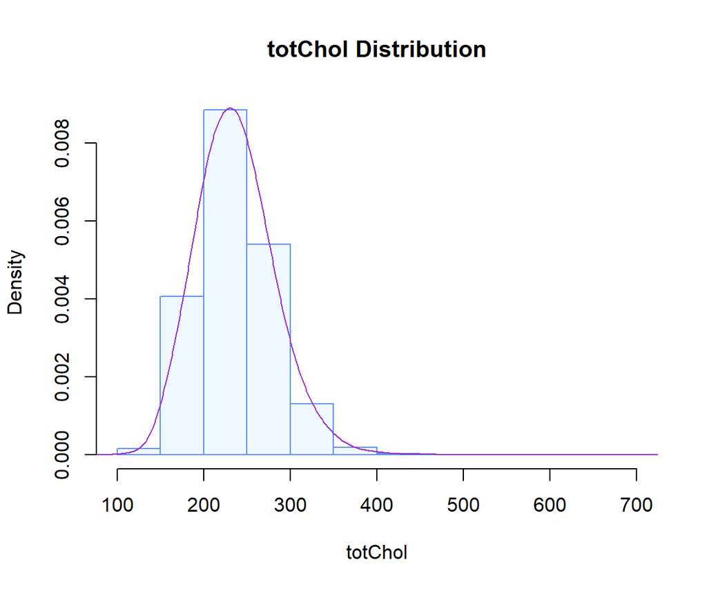

```r
ylimit = max(density(heartdisease1$totChol)$y)
hist(heartdisease1$totChol, probability = TRUE, main = "totChol Distribution", xlab="totChol",
       col = "aliceblue", border="cornflowerblue")
  lines(density(heartdisease1$totChol, adjust=2), col="darkorchid")
```

Overall, totChol appears to be unimodal and approximately normally distributed. Therefore we can say that this variable is safe to include within the multiple logistic regression model building process and that the process of filling in the missing observations did not lead to any severe concerns for the distribution of this variable.

### 2.4.2 BMI Distribution

BMI is another variable that had missing observations that were filled in during the previous steps. We will check its distribution to make sure it appears to be approximately normally distributed.

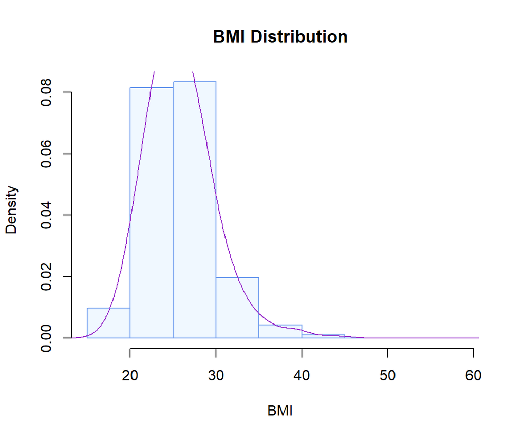

```r
ylimit = max(density(heartdisease1$BMI)$y)
hist(heartdisease1$BMI, probability = TRUE, main = "BMI Distribution", xlab="BMI",
       col = "aliceblue", border="cornflowerblue")
  lines(density(heartdisease1$BMI, adjust=2), col="darkorchid")
```

The distribution for BMI is unimodal and appears to be approximately normally distributed. It appears that the majority of individuals have a BMI somewhere in the range of 20-30, with the vast majority of the data falling within this range. This allows us to conclude that it is safe to include the variable of BMI within the multiple logistic regression model building process and that the process of filling in the missing values did not lead to any major concerns with the distribution of this variable.

### 2.4.3 Glucose Distribution

The variable glucose was another variable that had missing observations which were filled in during the previous steps. We will check its distribution to make sure that everything looks alright.

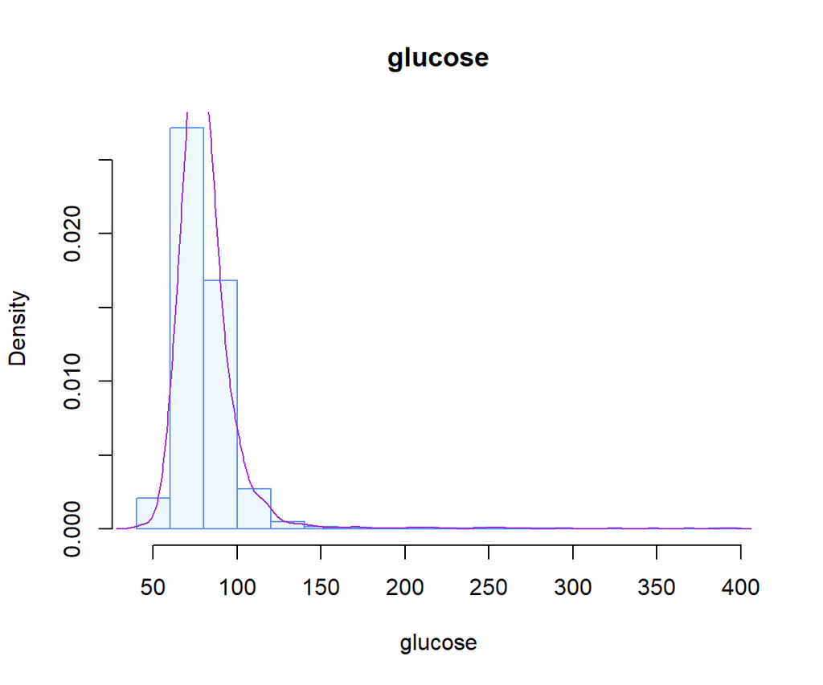

```r
ylimit = max(density(heartdisease1$glucose)$y)
hist(heartdisease1$glucose, probability = TRUE, main = "glucose", xlab="glucose",
       col = "aliceblue", border="cornflowerblue")
  lines(density(heartdisease1$glucose, adjust=2), col="darkorchid")
```

The variable glucose is unimodal and appears to be approximately normally distributed with the exception of a few outliers to the right. The most common glucose value appears to be around 75, with the histogram peaking around this value. Despite the few outliers, we will keep this variable in the final model since a patient’s glucose level is a medically important variable which would be helpful to know in order to assess a patient’s odds of being at risk for developing CHD.

### 2.4.4 cigsPerDay Distribution

cigsPerDay was another variable that had missing observations which were filled in during the previous steps. So, we should check its distribution to make sure things look alright.

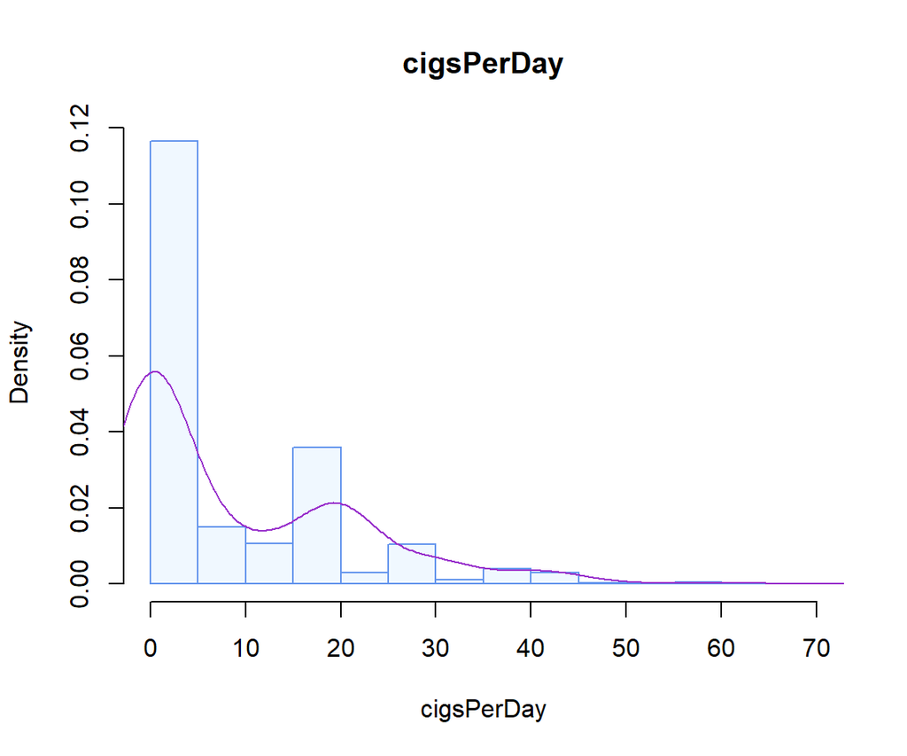

```r
ylimit = max(density(heartdisease1$cigsPerDay)$y)
hist(heartdisease1$cigsPerDay, probability = TRUE, main = "cigsPerDay", xlab="cigsPerDay",
       col = "aliceblue", border="cornflowerblue")
  lines(density(heartdisease1$cigsPerDay, adjust=2), col="darkorchid")
```

The variable cigsPerDay appears to be very notably skewed to the right. This can be attributed to that this variable represents the number of cigarettes a patient smokes per day. Many of the patients included in the data collection were not smokers, so they would have reported a value of 0 cigarettes smoked per day. This can explain the skew to the right of this variable, because non-smokers would report a value of 0 while smokers would report a value greater than 0 that represents the number of cigarettes they smoke in a day. This is a pratically important variable regardless of its skew, because smoking is a major risk factor for conditions like CHD. Additionally, this is an important piece of information, because doctors would want to know how many cigarettes their patients smoke in a day, because this has a significant impact on the patient’s risk factors. So, we will keep this variable in the final model despite its skew because it is an important variable in regards to a patient’s potential risk factors for developing CHD. But, it is important to keep in mind that this variable is skewed due to it being representative of both non-smokers and smokers.

### 2.4.5 heartRate Distribution

The variable heartRate was another one which had some missing observations that needed to be filled in during previous steps. We will check its distribution to ensure that everything looks alright.

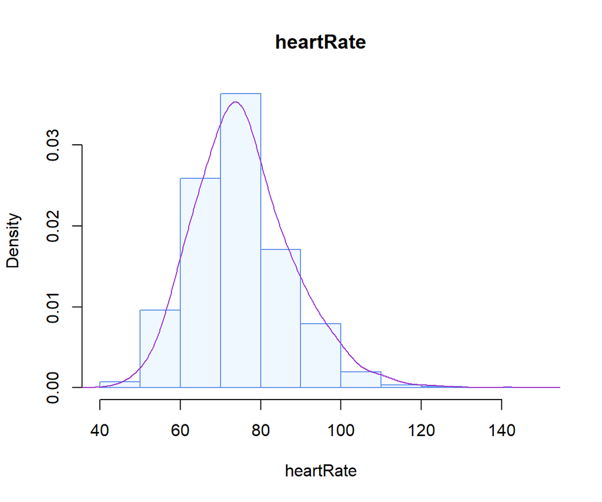

```r
ylimit = max(density(heartdisease1$heartRate)$y)
hist(heartdisease1$heartRate, probability = TRUE, main = "heartRate", xlab="heartRate",
       col = "aliceblue", border="cornflowerblue")
  lines(density(heartdisease1$heartRate, adjust=2), col="darkorchid")
```

The distribution for heart rate is unimodal and approximately normally distributed without any notable skew or outliers that are apparent in its density plot. This allows us to conclude that this variable is safe to include within the multiple logistic regression model building process and that the process of filling in the missing values did not lead to any issues in its distribution.

### 2.4.6 Overall Findings

We have checked the distributions of the variables which had missing observations that were filled in during the previous steps of this project along with other important quantitative variables in this data set. We ensured that the variables either follows a distribution that appears to be approximately normal, or are practically important enough to be included in the multiple logistic regression model building process otherwise.

The only variable that did not appear to follow an approximately normal distribution was cigsPerDay. However, the skewness seen in this variable’s distribution can be attributed to the fact that this data was collected amongst both smokers and non-smokers. So, non-smokers reported values of 0 cigarettes smoked per day, while smokers reported values that were greater than zero. This appeared to the distribution for this variable appearing to be skewed to the right. However, this is a variable that is practically important because the number of cigarettes a patient smokes per day can have a significant impact on their odds of being at risk for developing CHD. Due to the practical importance of this variable, it must still be included within the multiple logistic regression model building process.

Altogether, we have ensured that the variables in this data set appear to be good enough to use within the model building process. So, now we will begin with the process of building the candidate multiple logistic regression models.

# 3 Variable Transformation- Standardizing the Quantitative Variables

The main goal for this project is to find a model with the best predictive performance and power. In order to do so, we will standardize the quantitative variables in the data set to ensure that our data will be its best for predictive performance.

We will standardize all of the numeric, quantitative variables in order to give our data the best predictive power for the future model building we will conduct in the following steps.

```r
# Age
heartdisease1$sd.age = (heartdisease1$age-mean(heartdisease1$age))/sd(heartdisease1$age)

# cigsPerDay
heartdisease1$sd.cigsPerDay = (heartdisease1$cigsPerDay-mean(heartdisease1$cigsPerDay))/sd(heartdisease1$cigsPerDay)

# totChol
heartdisease1$sd.totChol = (heartdisease1$totChol-mean(heartdisease1$totChol))/sd(heartdisease1$totChol)

# sysBP
heartdisease1$sd.sysBP = (heartdisease1$sysBP-mean(heartdisease1$sysBP))/sd(heartdisease1$sysBP)

# diaBP
heartdisease1$sd.diaBP = (heartdisease1$diaBP-mean(heartdisease1$diaBP))/sd(heartdisease1$diaBP)

# BMI
heartdisease1$sd.BMI = (heartdisease1$BMI-mean(heartdisease1$BMI))/sd(heartdisease1$BMI)

# heartRate
heartdisease1$sd.heartRate = (heartdisease1$heartRate-mean(heartdisease1$heartRate))/sd(heartdisease1$heartRate)

# glucose
heartdisease1$sd.glucose = (heartdisease1$glucose-mean(heartdisease1$glucose))/sd(heartdisease1$glucose)
```

We will create a new data object to store the new standardized variables along with all of the binary and categorical predictor variables from the previous data set. We will call the new data set with all of the standardized quantitative variables “sd.heartdisease”.

```r
# New data set with original, non-standardized variables dropped.
sd.heartdisease = select(heartdisease1, -2,-5,-10:-15)
```

Now, all of the quantitative, numerical variables in the original data set have been standardized in order to ensure that our future model will have the best predictive power because the goal of this project is to create a model with the best predictive power and performance.

# 4 Data Split

We will now split the data up into training and testing data. We will randomly split the data so that 80% of the data will be used for training and 20% of the data will be used for testing. By splitting the data up into the training and the testing data, this will allow us to build the candidate models and analyze their predictive performances. We will use the split data to conduct the cross validation process to analysis the predictive power and performances of each of the three candidate models we will investigate. This will allow us to eventually determine which of these three models is the ideal choice for our final model based upon its overall predictive power.

```r
# Split the data into 80% training and 20% testing.
n <- dim(sd.heartdisease)[1]
train.n <- round(0.8*n)
train.id <- sample(1:n, train.n, replace = FALSE)

train <- sd.heartdisease[train.id, ]
test <- sd.heartdisease[-train.id, ]
```

Now, our data has been split up into a training and a testing data set, with 80% of the data for training and the remaining 20% for testing. The observations were split up randomly amongst these two data sets. We will specifically use the training data for the cross validation process. This process will allow us to identify which multiple logistic regression model is the best model for the purpose of prediction. This will allow us to select a model which predicts the odds of an individual being at risk for developing CHD with the highest quality of prediction.

# 5 Best Model Identification

Now that our variables have been checked and standardized to ensure their predictive performance being the best that it possibly can be, we will begin with the model building process. We will look at three potential, candidate models for the multiple logistic regression and determine which one has the best predictive performance.

## 5.1 Descriptions of the Three Candidate Models

We will take a look into the specifications of the three candidate multiple logistic regression models.

### 5.1.1 Full Model

The first of the three models will be the full model, with all of the variables included. This full model will use all of the variables in order to create a multiple logistic regression to predict the odds of a patient being at risk for developing CHD in a 10-year period.

The regression equation for this full model is represented as:

TenYearCHD = male + sd.age + education + currentSmoker + sd.cigsPerDay + BPMeds + prevalentStroke + prevalentHyp + diabetes + sd.totChol + sd.sysBP + sd.diaBP + sd.BMI + sd.heartRate + sd.glucose

We will find the specific multiple logisitic regression equation for this full model.

```r
full.model = glm(TenYearCHD ~ male + sd.age + education + currentSmoker + sd.cigsPerDay + BPMeds + prevalentStroke + prevalentHyp + diabetes + sd.totChol + sd.sysBP + sd.diaBP + sd.BMI + sd.heartRate + sd.glucose,
          family = binomial(link = "logit"),
          data = sd.heartdisease)
kable(summary(full.model)$coef,
      caption = "Full Model Summary of the Inferential Statistics")
```

Full Model Summary of the Inferential Statistics

|  | Estimate | Std. Error | z value | Pr(>\|z\|) |
| --- | --- | --- | --- | --- |
| (Intercept) | -2.2024269 | 0.1240704 | -17.7514313 | 0.0000000 |
| male | 0.4852112 | 0.1013449 | 4.7877196 | 0.0000017 |
| sd.age | 0.5168830 | 0.0539408 | 9.5824163 | 0.0000000 |
| education2 | -0.2356171 | 0.1154925 | -2.0401079 | 0.0413396 |
| education3 | -0.1026466 | 0.1376433 | -0.7457430 | 0.4558227 |
| education4 | 0.0115144 | 0.1519726 | 0.0757666 | 0.9396048 |
| currentSmoker | 0.0219380 | 0.1443470 | 0.1519811 | 0.8792019 |
| sd.cigsPerDay | 0.2507207 | 0.0679008 | 3.6924543 | 0.0002221 |
| BPMeds | 0.3270416 | 0.2170889 | 1.5064870 | 0.1319422 |
| prevalentStroke | 0.9388714 | 0.4468276 | 2.1011937 | 0.0356240 |
| prevalentHyp | 0.2311662 | 0.1287922 | 1.7948770 | 0.0726733 |
| diabetes | 0.0912436 | 0.3005700 | 0.3035687 | 0.7614565 |
| sd.totChol | 0.0803445 | 0.0457538 | 1.7560185 | 0.0790852 |
| sd.sysBP | 0.3074739 | 0.0783167 | 3.9260304 | 0.0000864 |
| sd.diaBP | -0.0327142 | 0.0713895 | -0.4582495 | 0.6467732 |
| sd.BMI | 0.0071253 | 0.0482202 | 0.1477649 | 0.8825283 |
| sd.heartRate | -0.0137062 | 0.0467007 | -0.2934898 | 0.7691478 |
| sd.glucose | 0.1729621 | 0.0500142 | 3.4582600 | 0.0005437 |

The equation for the multiple logistic regression equation of the full model is given as follows:

log p/(1-p) = -2.2024 + 0.4852 * male + 0.5169 * sd.age - 0.2356 * education2 - 0.1026 * education3 + 0.0115 * education4 + 0.0219 * currentSmoker+ 0.2507 * sd.cigsPerDay + 0.3270 * BPMeds + 0.9389 * prevalentStroke + 0.2312 * prevalentHyp + 0.0912 * diabetes + 0.0803 * sd.totChol + 0.3075 * sd.sysBP - 0.0327 * sd.diaBP + 0.0071 * sd.BMI - 0.0137 * sd.heartRate + 0.1730 * sd.glucose

### 5.1.2 Reduced Model

The second of the three models will be the reduced model. This model will consist only of the most practically important variables within the context of this situation, using various factors to best predict the odds of an individual being at risk for developing CHD. The United States National Library of Medicine of the National Institutes of Health (NIH), the most notable risk factors for an individual being at risk of developing CHD are cigarette smoking, blood pressure, and cholesterol levels. In this data set, there are two variables related to smoking, currentSmoker, whether a patient is currently a smoker or not, and cigsPerDay which is was scaled to sd.cigsPerDay, how many cigarettes a patient smokes in a day. There are also two variables related to blood pressure, sysBP and diaBP, for systolic blood pressure and diastolic blood pressure. Both of these blood pressure variables were scaled and are now given as sd.sysBP and sd.diaBP. There is also a variable included in the data set for a patient’s total cholesterol levels, totChol, which was scaled and is now given as sd.totChol. These five variables in the data set represent the key risk factors that the medical report from the NIH stated as being the most significant in predicting a patient’s risk for CHD. So, our reduced model will consist only of these particular variables.

The general regression equation for this reduced model is represented as:

TenYearCHD = currentSmoker + sd.cigsPerDay + sd.sysBP + sd.diaBP + sd.totChol

We will find the specific multiple logistic regression equation for this reduced model.

```r
reduced.model = glm(TenYearCHD ~ currentSmoker + sd.cigsPerDay + sd.sysBP + sd.diaBP + sd.totChol,
          family = binomial(link = "logit"),
          data = sd.heartdisease)
kable(summary(reduced.model)$coef,
      caption = "Reduced Model Summary of the Inferential Statistics")
```

Reduced Model Summary of the Inferential Statistics

|  | Estimate | Std. Error | z value | Pr(>\|z\|) |
| --- | --- | --- | --- | --- |
| (Intercept) | -1.7675361 | 0.0822320 | -21.494511 | 0.0000000 |
| currentSmoker | -0.1443498 | 0.1392986 | -1.036262 | 0.3000800 |
| sd.cigsPerDay | 0.2683287 | 0.0637373 | 4.209920 | 0.0000255 |
| sd.sysBP | 0.6381074 | 0.0641837 | 9.941893 | 0.0000000 |
| sd.diaBP | -0.1409295 | 0.0650918 | -2.165088 | 0.0303809 |
| sd.totChol | 0.1113871 | 0.0431866 | 2.579205 | 0.0099028 |

The equation for the multiple logistic regression equation of the reduced model is given as follows:

log p/(1-p) = -1.7675 - 0.1443 * currentSmoker + 0.2683 * sd.cigsPerDay + 0.6381 * sd.sysBP - 0.1409 * sd.diaBP + 0.1114 * sd.totChol

### 5.1.3 Forward Selection Model

The third of three candidate models will be the model that was found through the automatic variable selection process, specifically with using forward selection. We will call this the fs.model for this project to represent it being the model found through the use of forward selection of the variables.

We will find the specific multiple logistic regression equation for this forward selection model.

```r
fs.model = stepAIC(reduced.model, scope = list(lower=formula(reduced.model), upper=formula(full.model)),
                      direction = "forward",
                      trace = 0
                      )
kable(summary(fs.model)$coef,
      caption="Final Model Summary of the Inferential Statistics")
```

Final Model Summary of the Inferential Statistics

|  | Estimate | Std. Error | z value | Pr(>\|z\|) |
| --- | --- | --- | --- | --- |
| (Intercept) | -2.2897777 | 0.1108872 | -20.6496069 | 0.0000000 |
| currentSmoker | 0.0083694 | 0.1431896 | 0.0584499 | 0.9533902 |
| sd.cigsPerDay | 0.2497211 | 0.0677217 | 3.6874613 | 0.0002265 |
| sd.sysBP | 0.3080000 | 0.0777695 | 3.9604228 | 0.0000748 |
| sd.diaBP | -0.0324529 | 0.0698694 | -0.4644798 | 0.6423040 |
| sd.totChol | 0.0755135 | 0.0454483 | 1.6615237 | 0.0966083 |
| sd.age | 0.5363993 | 0.0527922 | 10.1605849 | 0.0000000 |
| male | 0.5164091 | 0.0993494 | 5.1979103 | 0.0000002 |
| sd.glucose | 0.1825977 | 0.0373944 | 4.8830291 | 0.0000010 |
| prevalentStroke | 0.9413243 | 0.4425788 | 2.1269078 | 0.0334277 |
| prevalentHyp | 0.2310484 | 0.1281164 | 1.8034261 | 0.0713213 |
| BPMeds | 0.3233004 | 0.2160729 | 1.4962560 | 0.1345870 |

The variables that were kept in this model after forward selection were currentSmoker, sd.cigsPerDay, sd.sysBP, sd.diaBP, sd.totChol, sd,age, male, sd.glucose, prevalentStroke, prevalentHyp, and BPMeds.

## 5.2 Cross Validation

Now that we’ve looked into the specifications of the three potential candidate models, we will use cross-validation to determine which of these three models we should use. We want to see which model has the best predictive performance. We will use a 5-fold cross validation to conduct the process of finding the predictive errors for each of the three candidate models. We will use this 5-fold cross validation process to calculate the average predictive errors for each of the three candidate models, the full model, the reduced model, and the forward selection model. We are looking for which model has the lowest value of average predictive errors. This model with the lowest value for the average predictive errors will be the ideal choice, as having the lowest predictive error value indicates a higher predictive power and more accurate predictions than a model with higher average predictive error would.

For our cross validation process, we will use a cut off probability of 0.5 to define between the binary response values of 1, yes, and 0, no. These values represent whether an individual will be stated as being at risk for developing CHD in a 10-year period based upon the multiple logistic regression model that was used for prediction.

We will label the full model as our first model (01), the reduced model as our second model (02), and the forward selection model as our third model (03) for this cross-validation process.

```r
## 5 Fold Cross Validation
k = 5
fold.size = floor(dim(train)[1]/k)
PE1 = rep(0,5)
PE2 = rep(0,5)
PE3 = rep(0,5)

# Training and Testing Fold for the Models
for(i in 1:k){

 valid.id = (fold.size*(i-1)+1):(fold.size*i)
  valid = train[valid.id, ]
  train.data = train[-valid.id,]

# Full Model: all variables
full.model = glm(TenYearCHD ~ male + sd.age + education + currentSmoker +  sd.cigsPerDay + BPMeds + prevalentStroke + prevalentHyp + diabetes + sd.totChol + sd.sysBP + sd.diaBP + sd.BMI + sd.heartRate + sd.glucose,
          family = binomial(link = "logit"),
          data = train.data)

## Reduced Model: only the most practically important variables.
reduced.model = glm(TenYearCHD ~ currentSmoker + sd.cigsPerDay + sd.sysBP + sd.diaBP + sd.totChol,
          family = binomial(link = "logit"),
          data = train.data)

## Automatic Forward Selection (fs) Model: model found using forward selection
fs.model = stepAIC(full.model,
                      scope = list(lower=formula(reduced.model),
                      upper=formula(full.model)),
                      direction = "forward",
                      trace = 0
                      )

# Finding the predicted probabilities for each of the candidate models
   pred.full = predict(full.model, newdata = valid, type = "response")
   pred.reduced = predict(reduced.model, newdata = valid, type = "response")
   pred.fs = predict(fs.model, newdata = valid, type = "response")

   pre.outcome01 = ifelse(as.vector(pred.full) > 0.5, "1", "0")
   pre.outcome02 = ifelse(as.vector(pred.reduced) > 0.5, "1", "0")
   pre.outcome03 = ifelse(as.vector(pred.fs) > 0.5, "1", "0")

   PE1[i] = sum(pre.outcome01 == valid$TenYearCHD)/length(pred.full)
   PE2[i] = sum(pre.outcome02 == valid$TenYearCHD)/length(pred.reduced)
   PE3[i] = sum(pre.outcome03 == valid$TenYearCHD)/length(pred.fs)
}

# Finding the average predictive errors of each candidate model
avg.pe = cbind(PE1 = mean(PE1), PE2 = mean(PE2), PE3 = mean(PE3))
kable(avg.pe, caption = "Average Predictive Errors of the Three Candidate Models")
```

Average Predictive Errors of the Three Candidate Models

| PE1 | PE2 | PE3 |
| --- | --- | --- |
| 0.8545723 | 0.8495575 | 0.8545723 |

The average predictive errors of the three candidate models are given as follows:

## 5.3 Final Model

```r
pred.reduced = predict(reduced.model, newdata = test, type = "response")
pred.reduced.outcome = ifelse(as.vector(pred.reduced) > 0.5, "1", "0")

Accuracy = sum(pred.reduced.outcome == test$TenYearCHD)/length(pred.reduced)
kable(Accuracy, caption="Actual Accuracy of the Final Model (Reduced Model)")
```

Actual Accuracy of the Final Model (Reduced Model)

| x |
| --- |
| 0.8443396 |

The actual accuracy of the final model, the reduced model, is given as 0.8443. This value represents the accuracy rate of this final model.

It appears that the final model has good accuracy as seen by its accuracy rate of 0.8443. This indicates that the final model we selected has good predictive performance for predicting the odds of an individual being at risk for developing CHD within a 10-year period.

# 6 ROC Analysis

We will use ROC analysis to measure the global performance of the multiple logistic regression model. This plot will illustrate the relationship of the true positive rate (TPR), also known as the sensitivity, against the false positive rate (FPR), also given as 1 - specificity. We will plot the ROC curves for each of the three candidate models to compare them against one another. We will also calculate the area under the curve (AUC) values for each of the three candidate models. The value of area under the curve represents the global goodness of the model, and a higher AUC value is ideal. A higher value of the area under the curve indicates better and more quality global goodness of that model.

We will plot the ROC curves for the full model, the reduced model, and the forward selection model. This will allow us to compare the area under the curves for each of the three models. Additionally, we will calculate the AUC values for each of the three models to compare them with each other and determine which model indicates the best global goodness.

```r
TPR.FPR=function(pred){
  prob.seq = seq(0, 1, length=50)
  pn = length(prob.seq)
  true.lab = as.vector(train$TenYearCHD)
  TPR = NULL
  FPR = NULL
  for (i in 1:pn){
   pred.lab = as.vector(ifelse(pred > prob.seq[i],"1", "0"))
   TPR[i] = length(which(true.lab=="1" & pred.lab=="1"))/length(which(true.lab=="1"))
   FPR[i] = length(which(true.lab=="0" & pred.lab=="1"))/length(which(true.lab=="0"))
  }
 cbind(FPR = FPR, TPR = TPR)
}
```

We will use the training data set to help find the predictive probabilities for each of the three candidate models.

```r
# The Full Model
full.model = glm(TenYearCHD ~male + sd.age + education + currentSmoker +  sd.cigsPerDay + BPMeds + prevalentStroke + prevalentHyp + diabetes + sd.totChol + sd.sysBP + sd.diaBP + sd.BMI + sd.heartRate + sd.glucose,
          family = binomial(link = "logit"),
          data = train)

# The Reduced Model (final model)
reduced.model = glm(TenYearCHD ~ currentSmoker + sd.cigsPerDay + sd.sysBP + sd.diaBP + sd.totChol,
          family = binomial(link = "logit"),
          data = train)

# The Forward Selection (fs) Model
fs.model = stepAIC(full.model,
                      scope = list(lower=formula(reduced.model),
                      upper=formula(full.model)),
                      direction = "forward",
                      trace = 0
                      )

# Finding the Predicted Probabilities for Each Model
pred.full = predict.glm(full.model, newdata = train, type = "response")
pred.reduced = predict.glm(reduced.model, newdata = train, type = "response")
pred.fs = predict.glm(fs.model, newdata = train, type = "response")
```

Now, we will plot the ROC curves for each of the three candidate models to compare them.

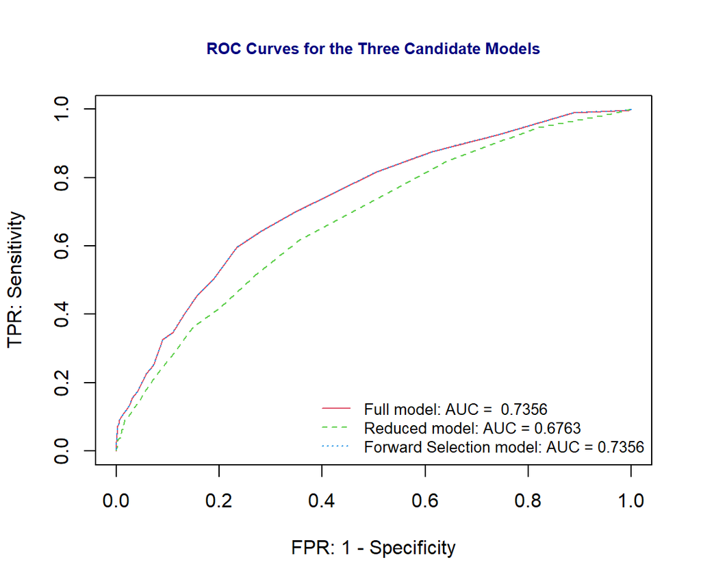

```r
# Plotting the ROC curves
 plot(TPR.FPR(pred.full)[,1], TPR.FPR(pred.full)[,2],
      type="l", col = 2, lty = 1, xlim = c(0,1), ylim = c(0,1),
      xlab = "FPR: 1 - Specificity",
      ylab ="TPR: Sensitivity",
      main = "ROC Curves for the Three Candidate Models",
      cex.main = 0.8,
      col.main = "navy")
 lines(TPR.FPR(pred.reduced)[,1], TPR.FPR(pred.reduced)[,2],  col=3, lty=2)
 lines(TPR.FPR(pred.fs)[,1], TPR.FPR(pred.fs)[,2],  col=4, lty=3)

  category = train$TenYearCHD == "1"
  ROCobj01 <- roc(category, as.vector(pred.full))
  ROCobj02 <- roc(category, as.vector(pred.reduced))
  ROCobj03 <- roc(category, as.vector(pred.fs))
  AUC01 = round(auc(ROCobj01),4)
  AUC02 = round(auc(ROCobj02),4)
  AUC03 = round(auc(ROCobj03),4)

  legend("bottomright", c(paste("Full model: AUC = ", AUC01),
                         paste("Reduced model: AUC =", AUC02),
                         paste("Forward Selection model: AUC =", AUC03)),
        col = 2:4, lty = 1:3, cex = 0.8, bty = "n")
```

We can see that both the full model and the forward selection model fall on the exact same curve, which is also evidenced by how these two models have the same values for their area under the curve Both the full model and the forward selection model have an area under the curve of 0.7356, and their ROC curves match up identically to each other. This matches up with the previous finding of the full model and the forward selection model having the exact same values for their average predictive errors.

# 7 Conclusion

In this project, three candidate models were created to compare their predictive powers and ultimately choose a final model that provides the best significance and quality of prediction for predicting the odds of an individual being at risk for developing CHD in a 10-year period. These models all consisted of multiple logistic regression to predict the binary response variable of an individual’s odds of being at risk for developing CHD. Creating a model for the purpose of this prediction can provide use for doctors and patients in order to predict their odds of being at risk for developing CHD based upon various personal and medical factors.

The three candidate models that were created included a full model with all of the variables in the data set, a reduced model with only the variables deemed as the most practically important, and a model created through forward variable selection. These three models were compared by their predictive power and quality for their potential use as a final multiple logistic regression model for this project.

## 7.1 Recommendations

# 8 References

This data set was found on kaggle.com under the collection of logistic regression data sets. Included below is the citation of the web page of where I found the data set I used for my project along with the medical report I found which described which factors are the most medically significant when it comes to determining a patient’s risk for developing CHD.

Dileep. (2019, June 7). Logistic regression to predict heart disease. Kaggle. https://www.kaggle.com/datasets/dileep070/heart-disease-prediction-using-logistic-regression?resource=download&select=framingham.csv

Hajar, R. (2017). Risk factors for coronary artery disease: Historical perspectives. Heart views : the official journal of the Gulf Heart Association. https://pmc.ncbi.nlm.nih.gov/articles/PMC5686931/